[figure not shown]

Welcome to the results of the Leader Network Diagnostic. The purpose of this document is to help you understand your core professional network.

## Network Visualization

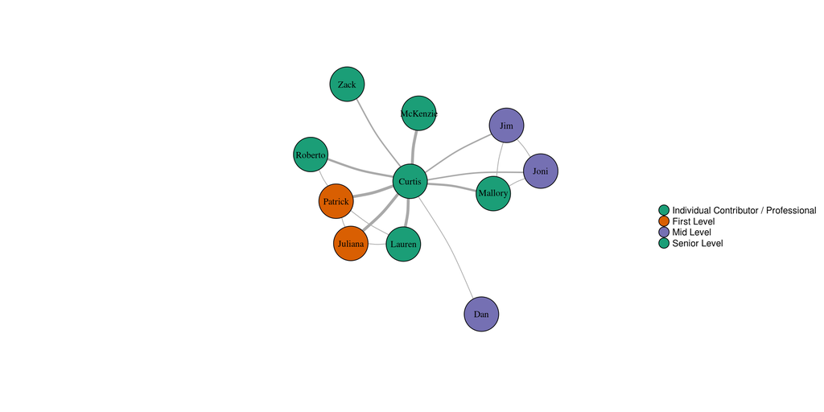

## Open

*Your openness score is 100.*

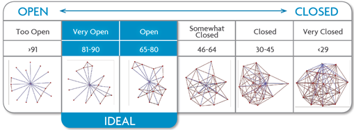

**You have ample opportunities in your network to gain value, but maintaining strong enough ties across the wide variety of groups comes at a significant cost to your time and effort.**

- You likely have an abundance of weak ties to hear new information, but you may not have strong enough ties to leverage this information. This situation does not benefit you or your network. It is time to begin organizing and focusing your network.
- You can begin organizing your network by brokering a few relationships between separate groups. If successful, these connections will provide you with stronger ties, which will allow you to have better knowledge transfer and increased opportunities throughout your network for both you and the brokered relationships.
- Streamline your network by letting go of unproductive relationships that take disproportionate time and effort to maintain. Let contacts go dormant, especially if you have previously built strong ties.

## Diverse

*Your network is 88.1% diverse.*

**A diverse network means you cross 3 or more boundaries.**

Like having an open network, you have opportunities to pass along information and resources between groups. However, you need to ask if the boundaries you are crossing help you achieve your goals.

- While boundary spanning may bring new information into a network, its benefits can still be hampered when the groups you connect to are similar to each other. Make sure the boundaries that you are crossing bring unique value into your network.
- Leverage the differentiation and benefits from the different boundaries. Make sure your team is aware of the knowledge and relationships you have across these different groups. Do not hesitate to make an introduction if it provides value to both parties involved.
- Evaluate the boundaries you span and determine if they help you achieve your goals. If they do not, identify the team, group, etc., where you would like to connect and begin the process of building relationships.

- To stay relevant and fully resourced, evaluate whether you have the appropriate strategic relationships (those that provide insights into the future of you and your team’s work). If you don’t, identify which boundaries could provide additional value.
- In order to access new information, you may need to branch out of the one or two groups where you spend all your time. Leverage your current strong and weak ties to identify and build relationships with a few individuals across the new boundary.
- Free up some of your time to add a new boundary to your network. This may require that you delegate more of your current responsibilities to others in your network.

## Deep

*64% of the relationships in your network are close or very close*

A network that has a balanced depth has an equal mix of close/very close and not close/distant relationships. This is an ideal network because the mixture of old ties and new ties, strong and weak ties is more likely to bring you benefits from trust and knowledge transfer (strong ties), as well as novel and unique information (weak ties).

- Evaluate your network to ensure that your strong and weak ties are spread across your different boundaries. If not, identify and make new relationships with connections across strategic boundaries.
- A balanced overall network may not necessarily mean that you have balanced ties within each boundary. You should have at least one close or very close tie across each of your boundaries to gain the biggest benefit. Ensure your strong ties are not all invested in one group.

## Additional Information

**This graphic shows the different ways people are helpful in your network.**

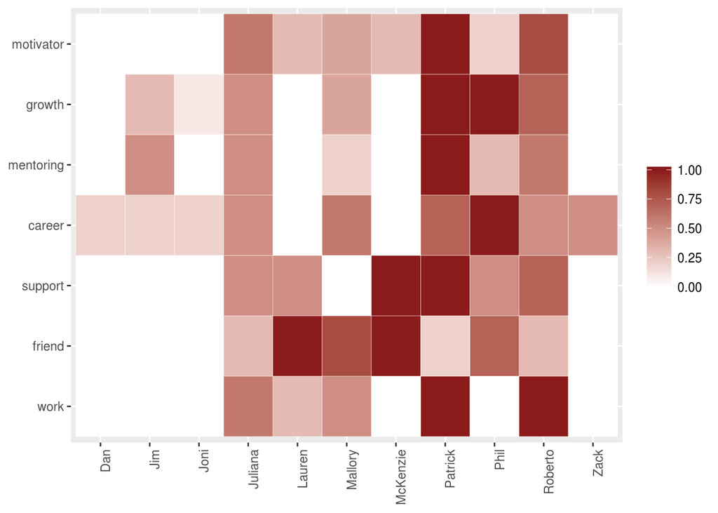